## 空間分析 期中考一

#### 助教 杜承軒 2020.04.03

> > 一、概念題 (12點)

> 現有東京都行政區(面資料)，以及東京都內國鐵車站（點資料）等GIS圖資。將這兩筆圖資擬在R進行疊圖分析，東京都行政區命名為Tokyo，資料格式SpatialPolygonsDataFrame，投影座標為EPSG:4326，東京都內國鐵車站命名為JR，資料格式SpatialPointsDataFrame，投影座標為EPSG:3095。已知東京都的範圍約介於139°E~140°E、35.5°N~36°N之間。  
> 分析目的將東京都行政區與東京都內國鐵車站進行圖資疊合。下列是五位同學(A, B, C, D, E)撰寫的程式碼，請判斷哪些同學的程式碼能夠成功疊圖？若答案為否，請更正程式碼使其能夠成功執行疊圖（更正正確才給分）。

```r
proj4string(JR)=proj4string(Tokyo)
plot(Tokyo)
points(JR)
```

```
## 否，第1行改成：JR=spTransform(JR,Tokyo@proj4string)
```

```r
spTransform(Tokyo,JR@proj4string)
plot(Tokyo)
points(JR)
```

```
## 否，第1行改成：Tokyo=spTransform(Tokyo,JR@proj4string)
```

```r
TK.f=fortify(spTransform(Tokyo,CRS('+init=epsg:3095')))
ggplot()+geom_polygon(data=TK.f,aes(x=long,y=lat,group=group))+
          geom_point(aes(x=JR@coords[,1],y=JR@coords[,2]))
```

```
## 是
```

```r
map=openmap(c(139,36),c(140,35.5),12,'esri-topo')
plot(map)
points(spTransform(JR,CRS('+init=epsg:4326')))
```

```
## 否
## 第1行改成：map=openmap(c(36,139),c(35.5,140),12,'esri-topo')→經緯度相反
## 第3行改成：points(spTransform(JR,osm())
## 或，第3行改成：points(spTransform(JR,CRS('+init=epsg:3857'))
```

```r
new.Tokyo=spTransform(Tokyo,CRS('+init=epsg:4326'))
new.JR=spTransform(JR,CRS('+init=epsg:4326'))
min=c(new.Tokyo@bbox[2,1],new.Tokyo@bbox[1,1])
max=c(new.Tokyo@bbox[2,2],new.Tokyo@bbox[1,2])
map=openmap(min,max,13,'osm')
plot(map)
plot(new.Tokyo,add=T)
plot(new.JR,add=T)
```

```
## 否
## 第5~6行之間加入：map=openproj(map,CRS(+init=epsg:4326))
## 或，第7行改成：plot(spTransform(new.Tokyo,osm()),add=T)
## 　　第8行改成：plot(spTransform(new.JR,osm()),add=T)
```

> > 二、實作題 (38點)

＊初步環境建置與讀取檔案

```r
library(ggplot2);library(GISTools);library(rgdal);library(dplyr)
windowsFonts(JH = windowsFont("微軟正黑體"))
setwd("D:/1082SA/Mid1/Data/")
SW=readOGR("Taiwan_SW.shp",encoding = "unicode")
PH=readOGR("pharmacy.shp")
sample=read.csv("sample.csv")
```

> > 1. ggplot繪製面量圖

> 定義鄉鎮藥局服務量（間／萬人）＝該鄉鎮藥局數量（間）÷該鄉鎮總人口（萬人）。  
> 目標繪製出臺南市各鄉鎮市區的服務量面量圖，以及臺南市藥局分布點位。

> (1) 計算出臺南市各鄉鎮市區服務量，並以平均─標準差分類法分成五類。

轉換成一致的座標系統後，計算、整理各鄉鎮的人口、面積、藥局數、服務量

```r
SW=spTransform(SW,PH@proj4string)
SW$pop=SW$A0A14_CNT+SW$A15A64_CNT+SW$A65UP_CNT
SW$area=poly.areas(SW)/10^6
SW$pharmacy=poly.counts(PH,SW)
SW$service=SW$pharmacy/SW$pop*10^4
```

篩選出台南市的藥局點位

```r
TN=SW[SW$COUNTY=='臺南市',]
PH.TN=PH[colSums(gWithin(PH,TN,byid=T))==1,]
#或是
#PH.TN=gIntersection(PH,TN)
```

以「平均─標準差法」分組

```r
TN.shade=auto.shading(TN$service,4,sdCuts,cols = brewer.pal(5,"RdBu"))
TN$class=cut(TN$service,c(-Inf,TN.shade$breaks,Inf),labels = 1:5)
#或是
m=mean(TN$service);sd=sd(TN$service)
TN$class=cut(TN$service,c(-Inf,m-1.5*sd,m-0.5*sd,m+0.5*sd,m+1.5*sd,Inf),labels = 1:5)
xtabs(~TN$class)
```

```
## TN$class
##  1  2  3  4  5
##  2 11 12  9  3
```

> (2) 透過ggplot2套件，繪製臺南市服務量面量圖，以及臺南市藥局分布點位。

一般方法繪圖

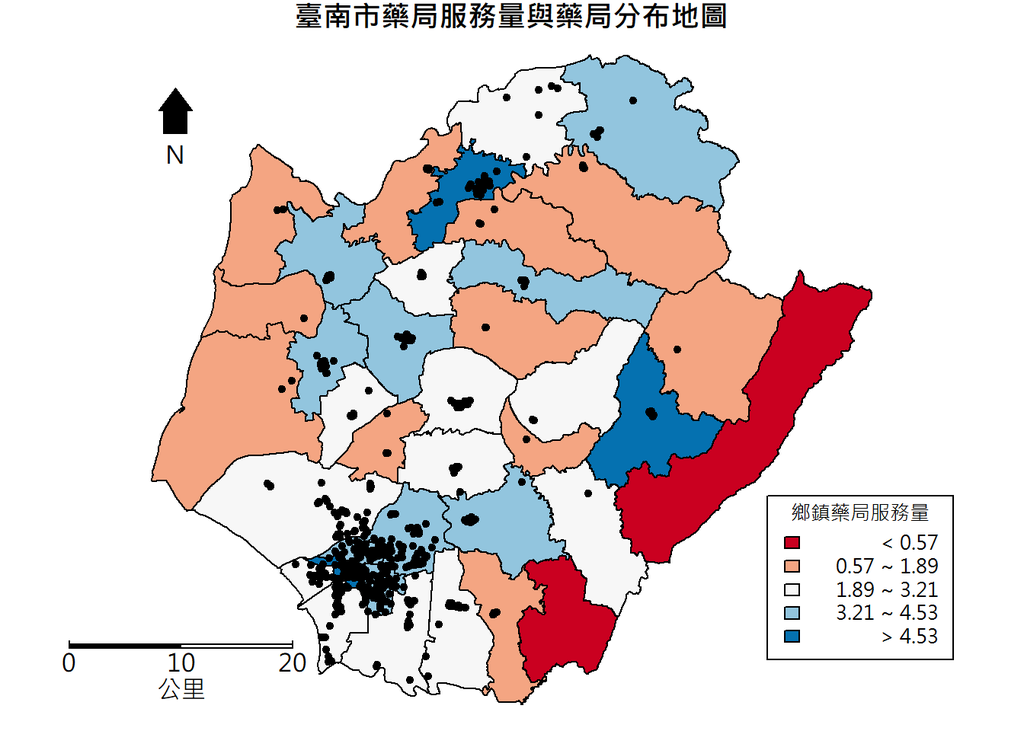

```r
par(mar=c(0,1,1,1),family ="JH")
choropleth(TN,TN$service,TN.shade, main = "臺南市藥局服務量與藥局分布地圖")
map.scale(152946,2537068,20000, "公里",2,10) #比例尺
north.arrow(152416,2583206,1000,lab='N',col='black') #指北針
choro.legend(205459,2550674,TN.shade,under="<",over=">",between="~",fmt = "%.2f",cex=0.8,title="鄉鎮藥局服務量") #圖例
points(PH.TN,pch=20)
```

ggplot繪圖

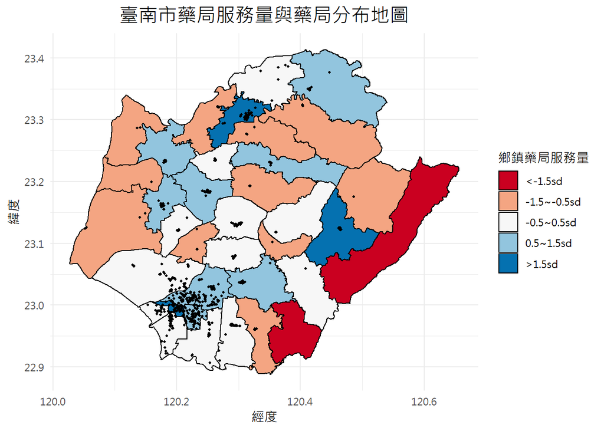

```r
#以經緯度網格來繪圖需先轉換CRS
TN=spTransform(TN,CRS("+init=epsg:4326"))
PH.TN=spTransform(PH.TN,CRS("+init=epsg:4326"))
#進行fortify，再將資料對回後繪圖
TN.f=fortify(TN,region="TOWN")
TN.f=left_join(TN.f,TN@data,by=c("id"="TOWN"))
ggplot()+geom_polygon(data=TN.f,aes(x=long,y=lat,group=group,fill=class),col='black')+coord_equal()+
  scale_fill_manual("鄉鎮藥局服務量",values=brewer.pal(5,"RdBu"),labels=c("<-1.5sd","-1.5~-0.5sd","-0.5~0.5sd","0.5~1.5sd",">1.5sd"))+
  geom_point(aes(x=PH.TN@coords[,1],y=PH.TN@coords[,2]),size=0.8)+
  theme_minimal()+labs(title ="臺南市藥局服務量與藥局分布地圖",x="經度",y="緯度")+
  theme(legend.position = "right",plot.title = element_text(size=16,hjust = 0.5),text=element_text(family="JH"))
```

> > 2. 計算服務受限人數

> 假設藥局的服務範圍為1 km，且服務範圍不受行政區邊界限制，並預設在鄉鎮內的人口是均勻分布的。請利用鄉鎮市區服務範圍的面積比例，計算出「嘉義縣、嘉義市無法被藥局所服務到的人數」分別為多少人？

「藥局一公里環域」與「嘉義縣市」面資料，進行截切，計算各鄉鎮服務範圍面積

```r
CY=SW[SW$COUNTY%in%c("嘉義縣","嘉義市"),]  #將嘉義縣市的鄉鎮取出
PH1K=gBuffer(PH,width=1000) #藥局一公里環域，融合環域結果即可，因此byid=F
CY1K=gIntersection(CY,PH1K,byid=T) #計算各鄉鎮x各藥局服務範圍
CY.id=unlist(lapply(strsplit(names(CY1K)," "),function(x) x[1])) #取出鄉鎮id
CY1K.area=poly.areas(CY1K)/10^6 #計算各鄉鎮x各藥局服務範圍面積
```

服務範圍面積對回CY資料

```r
#將服務範圍面積對回CY資料
CY$area1K=0
for(i in 1:length(CY.id))  CY[CY.id[i],'area1K']=CY1K.area[i]
#或是用left_join將CY資料對回截切資料
CY.data=data.frame(CY.id,CY1K.area)
CY$CY.id=rownames(CY@data)
CY.data=left_join(CY.data,CY@data)
#注意：這個步驟會有一個鄉鎮資料(大埔鄉)消失，只能算影響人口，直接算未被影響人口會有誤(參考下面的方法)
```

計算出各鄉鎮不在服務範圍的人口，再加總至縣市

```r
CY$nosevrice=round((1-CY$area1K/CY$area)*CY$pop)
CY$COUNTY=as.character(CY$COUNTY)
data.frame(xtabs(nosevrice~COUNTY,CY))
```

```
##   COUNTY   Freq
## 1 嘉義市 119964
## 2 嘉義縣 440919
```

```r
#或是
CY.data$popsevrice=round((CY.data$area1K/CY.data$area)*CY.data$pop)
total=xtabs(pop~COUNTY,SW@data)
popsevrice=xtabs(popsevrice~COUNTY,CY.data)
nosevrice=data.frame(total-popsevrice)
nosevrice[nosevrice$COUNTY%in%c("嘉義市","嘉義縣"),]
```

```
##   COUNTY   Freq
## 2 嘉義市 119964
## 3 嘉義縣 440919
```

> > 3. 評估藥局可近性差異

> 隨機抽樣藥局來調查空間中供需分配關係，結果如sample.csv。  
> 定義藥局可近性分數＝藥品供給量÷（服務範圍內人口數÷服務範圍內藥局總數量），其中，藥品供給量及服務範圍內人口數請直接使用csv內的supply、pop欄位。服務範圍內藥局總數量，則請自行計算該藥局服務範圍 (1 km環域) 的藥局總數量。  
> 請從抽樣的藥局中，再篩選出臺南市與雲林縣的藥局(csv內的COUNTY欄位)，利用統計檢定方法，評估臺南市與雲林縣藥局之平均可近性分數是否有顯著差異。

將抽樣的藥局資料對回pharmacy.shp，並篩選出來。計算抽樣藥局服務範圍內的藥局總數，再計算可近性分數。

```r
sample$id=as.character(sample$id)
PH@data=left_join(PH@data,sample)
PH.sample=PH[!is.na(PH$pop),]
PH.sample$count=rowSums(gWithinDistance(PH,PH.sample,dist=1000,byid=T))
PH.sample$access=PH.sample$supply/(PH.sample$pop/PH.sample$count)
```

1. $設定顯著水準為{\alpha=0.05}$  
   $H_0:臺南市與雲林縣藥局之平均可近性分數相同$  
   $H_a:臺南市與雲林縣藥局之平均可近性分數不同$  
   $若令臺南市與雲林縣藥局之平均可近性分數分別為\mu_1及\mu_2$  
   $則H_0:\mu_1=\mu_2，H_a:\mu_1\neq\mu_2$
2. $因假設兩地區藥局可近性分數之分布皆呈常態分配，且兩者變異數相等 → 使用t檢定(pooled)即可。$

```r
two.t=t.test(access~COUNTY,data=PH.sample,var.equal=T)
two.t
```

```
##
##  Two Sample t-test
##
## data:  access by COUNTY
## t = -3.4093, df = 77, p-value = 0.001039
## alternative hypothesis: true difference in means is not equal to 0
## 95 percent confidence interval:
##  -3.0929080 -0.8121283
## sample estimates:
## mean in group 雲林縣 mean in group 臺南市
##             7.673326             9.625844
```

```r
sprintf("t分數=%.4f",two.t$statistic)
```

```
## [1] "t分數=-3.4093"
```

3. $計算p值(雙尾)。$

```r
sprintf("p值=%.4f",two.t$p.value)
```

```
## [1] "p值=0.0010"
```

4. $p值=0.001<0.05=\alpha，因此拒絕虛無假設H_0。$
5. $結論：臺南市與雲林縣藥局之平均可近性分數有顯著地不同。$